# Urban Tree Health Monitoring Report

## Introduction to Urban Tree Health

This visual story conducts an in-depth analysis of the park trees in Auckland, highlighting the growth patterns of specific species, weekly development trends, and stress factors related to pests based on 40 observations collected from April 1st to May 10th.

Our analysis emphasizes three key aspects: species-specific growth patterns to understand how different types of trees grow over time; weekly growth trends to monitor the impact of seasons or the environment on growth; and pest-related stress factors to identify potential threats to the health of trees in Auckland parks.

## Species Growth Analysis

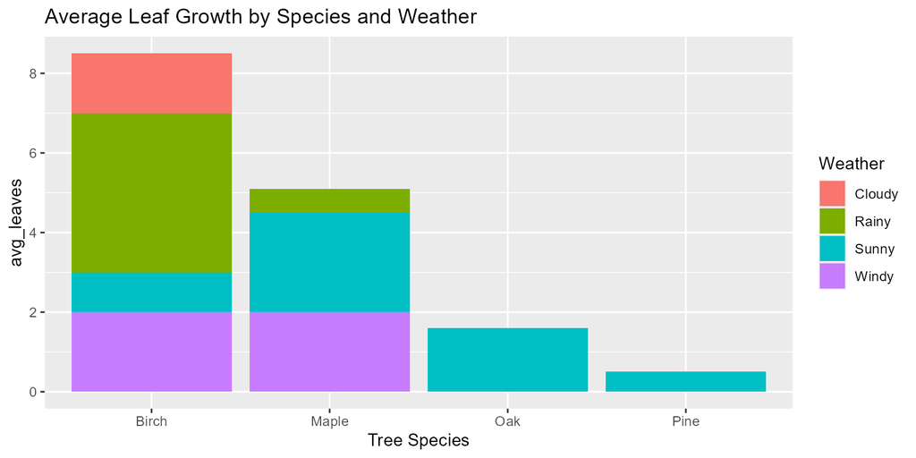

I wanted to observe how the leaf growth of different kinds of trees was in different weather, but it was not very realistic to count how many new leaves there were, so I decided to use the new growth of branch instead of the leaf grwoth condition. According to plot 1 we can see that birch has the most leaves, with the best leaf growth on rainy days. The second best leaf growth is in cloudy and windy weather. The least growth was on sunny days, and the opposite was true for maple, which grew the most on sunny days and the least on rainy days. Oak and Pine were observed to have leaf growth only on sunny days.